# Outliers and Correlation

## 1. Importing the libraries

Let us import the essential libraries first.

```python
import pandas as pd
import matplotlib.pyplot as plt
```

## 2. Reading the data

We would be working on 'advertising.csv' dataset so let us read it using pandas 'pd'.

```python
data = pd.read_csv("advertising.csv")
```

```python
data
```

|  | TV | Radio | Newspaper | Sales |
| --- | --- | --- | --- | --- |
| 0 | 230.1 | 37.8 | 69.2 | 22.1 |
| 1 | 44.5 | 39.3 | 45.1 | 10.4 |
| 2 | 17.2 | 45.9 | 69.3 | 12.0 |
| 3 | 151.5 | 41.3 | 58.5 | 16.5 |
| 4 | 180.8 | 10.8 | 58.4 | 17.9 |
| ... | ... | ... | ... | ... |
| 195 | 38.2 | 3.7 | 13.8 | 7.6 |
| 196 | 94.2 | 4.9 | 8.1 | 14.0 |
| 197 | 177.0 | 9.3 | 6.4 | 14.8 |
| 198 | 283.6 | 42.0 | 66.2 | 25.5 |
| 199 | 232.1 | 8.6 | 8.7 | 18.4 |

200 rows × 4 columns

## 3. Identifying Outliers using boxplot

Let us plot a boxplot to understand the concept of outliers.

Outliers are the values that skew away from the original dataset. In simple words, the values that are a deviation from the original dataset.

Let us first start plotting boxplot for all the columns in data.

To plot a boxplot on TV column we use the syntax as follows:

```
{'whiskers': [<matplotlib.lines.Line2D at 0x1b528c822d0>,
 'caps': [<matplotlib.lines.Line2D at 0x1b528c83c90>,
 'boxes': [<matplotlib.lines.Line2D at 0x1b528c81410>],
 'medians': [<matplotlib.lines.Line2D at 0x1b528bb0e90>],
 'fliers': [<matplotlib.lines.Line2D at 0x1b528c046d0>],
 'means': []}
```

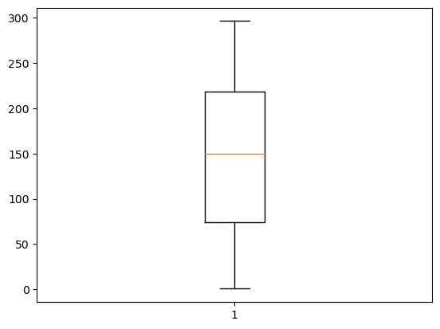

```python
column = data["TV"]
plt.boxplot(column)
```

Let us understand the above o/p (boxplot) now.

So in the above boxplot, the upper and lower horizontal lines are called upper & lower whiskers.

The line inside the box is the median and the box itself indicates how many values lie close to the median. For the above diagram, we've no outliers or in other words we do not have any values that are outside the boxplot on the extreme ends of the plot.

Let us check for another column 'Radio'.

```
{'whiskers': [<matplotlib.lines.Line2D at 0x1b528d6fdd0>,
 'caps': [<matplotlib.lines.Line2D at 0x1b528d81590>,
 'boxes': [<matplotlib.lines.Line2D at 0x1b528d6ca50>],
 'medians': [<matplotlib.lines.Line2D at 0x1b528d82c10>],
 'fliers': [<matplotlib.lines.Line2D at 0x1b528aa3490>],
 'means': []}
```

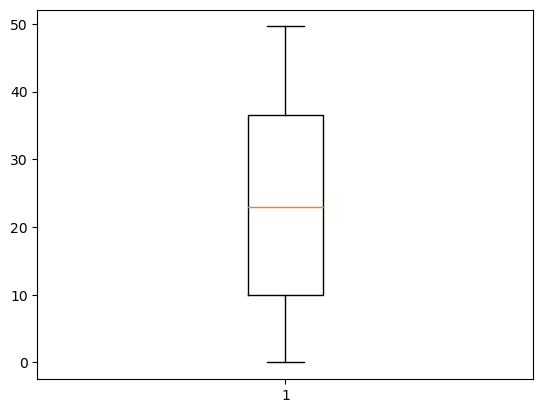

```python
column = data["Radio"]
plt.boxplot(column)
```

Again we got a decent boxplot without any outliers. Now let us check the column 'Newspaper'.

```
{'whiskers': [<matplotlib.lines.Line2D at 0x1b528ddba10>,
 'caps': [<matplotlib.lines.Line2D at 0x1b528c931d0>,
 'boxes': [<matplotlib.lines.Line2D at 0x1b528ddad50>],
 'medians': [<matplotlib.lines.Line2D at 0x1b528dea390>],
 'fliers': [<matplotlib.lines.Line2D at 0x1b528dead50>],
 'means': []}
```

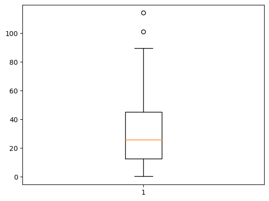

```python
column = data["Newspaper"]
plt.boxplot(column)
```

As evident from the figure above, there are 2 co-ordinates that skew/deviate from the original data. These co-ordinates are called as Outliers.

**Any values that lie beyond the upper and lower whiskers are called as Outliers.**

So now, if we want to eliminate the outliers in this case, we've to consider the data that lies below the threshold of the upper whisker (which is 90).

```python
data_new = data[data["Newspaper"]< 90]
```

```python
data_new
```

|  | TV | Radio | Newspaper | Sales |
| --- | --- | --- | --- | --- |
| 0 | 230.1 | 37.8 | 69.2 | 22.1 |
| 1 | 44.5 | 39.3 | 45.1 | 10.4 |
| 2 | 17.2 | 45.9 | 69.3 | 12.0 |
| 3 | 151.5 | 41.3 | 58.5 | 16.5 |
| 4 | 180.8 | 10.8 | 58.4 | 17.9 |
| ... | ... | ... | ... | ... |
| 195 | 38.2 | 3.7 | 13.8 | 7.6 |
| 196 | 94.2 | 4.9 | 8.1 | 14.0 |
| 197 | 177.0 | 9.3 | 6.4 | 14.8 |
| 198 | 283.6 | 42.0 | 66.2 | 25.5 |
| 199 | 232.1 | 8.6 | 8.7 | 18.4 |

198 rows × 4 columns

Since, we are filtering the dataset to choose values less than 90, we should get a boxplot without outliers. Let us check the boxplot now.

```
{'whiskers': [<matplotlib.lines.Line2D at 0x1b528e42f50>,
 'caps': [<matplotlib.lines.Line2D at 0x1b528e48650>,
 'boxes': [<matplotlib.lines.Line2D at 0x1b528e42350>],
 'medians': [<matplotlib.lines.Line2D at 0x1b528e49c50>],
 'fliers': [<matplotlib.lines.Line2D at 0x1b528e123d0>],
 'means': []}
```

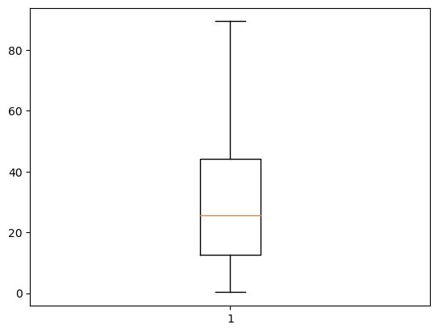

```python
plt.boxplot(data_new["Newspaper"])
```

This is one of the ways one can eliminate outliers from the data.

Let us move further to understand what correlation is.

## 4. Understanding Correlation

Correlation tells how different columns in the dataset are related to each other.

To define Correlation: One unit change in one coulmn will translate to how many units change in another column.

There are 3 types of Correlation:

```
Positive correlation: Direct proportionality b/w 2 columns.
                      If one increases another increases, if one decreases another decreases.

Negative correlation: Inverse proportionality b/w 2 columns.
                       If one increases other decreases, if one decreases other increases.

No correlation      : No relation or dependancy b/w 2 columns.
                      One's increase or decrease does not affect the other column.
```

### 4.1 Positive Correlation & No Correlation

To check for an example of positive correlation, let us see the following example.

Here, we are performing EDA using matplotlib. This time we are plotting a scatter plot.

Initially we define column_a & column_b as dataframe consisting of 'TV' & 'Sales' data.

It is then followed by plotting a scatter plot of column_a & column_b.

The syntax would be: **plt.scatter(Co-ordinates_from_X_axis,Co-ordinates_from_Y_axis)**

It is then followed by defining the x,y labels and lastly the title of the plot.

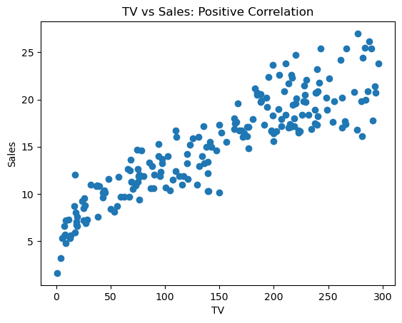

```python
column_a = data["TV"]
column_b = data["Sales"]

plt.scatter(column_a,column_b)
plt.xlabel("TV")
plt.ylabel("Sales")
plt.title("TV vs Sales: Positive Correlation")
```

Here as evident from the o/p above there exists are a strong linear correlation b/w TV and Sales. This indicates that with increase in TV revenue, Sales is increasing as well. This is what we define as a Positive correlation.

Let us check the same for the column "Radio" & "Sales"

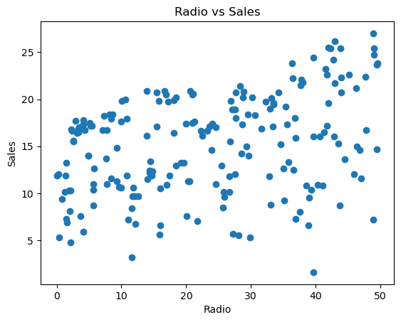

```python
column_c = data["Radio"]
column_d = data["Sales"]

plt.scatter(column_c,column_d)
plt.xlabel("Radio")
plt.ylabel("Sales")
plt.title("Radio vs Sales")
```

Let us check for the columns 'Newspaper' & 'Sales' now.

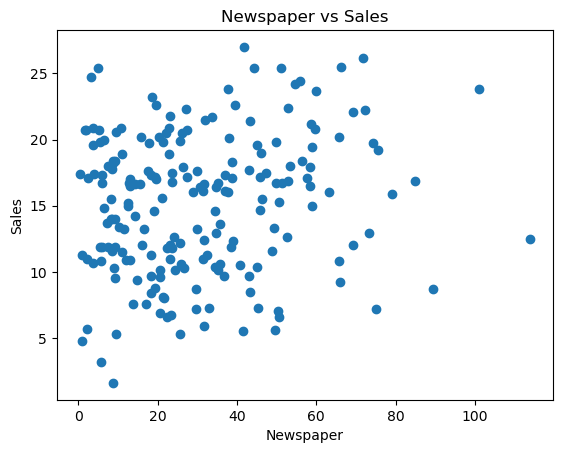

```python
column_e = data["Newspaper"]
column_f = data["Sales"]

plt.scatter(column_e,column_f)
plt.xlabel("Newspaper")
plt.ylabel("Sales")
plt.title("Newspaper vs Sales")
```

### 4.2 Heatmap

One alternate EDA which is more frequently used to check correlation is called as 'heatmap'.

Heatmap is a matrix plot of correlations between columns within the data.

In a heatmap, The value of Correlation spans b/w -1 0 and 1:

**-1 or closer values: Negative correlation**

**0 or closer values: No correlation**

**1 or closer values: Positive correlation**

We use seaborn as a library to visualize heatmap. The syntax used is : **sns.heatmap(dataset_name.corr(), annot= True)**.

.corr() is a method used to plot the correlation matrix, whereas annot = True is used to annote values (dispay the correlation values) on the matrix.

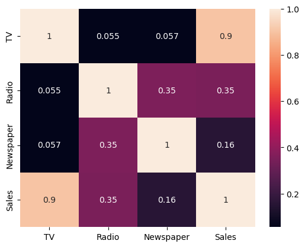

```python
import seaborn as sns
sns.heatmap(data.corr(), annot=True) # annot means annotation, it will assign values to the heatmap.
```

Let us interpret the heatmap above.

The strip on it's right side gives us the value of correlation. Lighter shade (values closer to 1.0) gives higher correlation and Darker shade (values closer to 0.2) gives lower correlation.

The data in the diagonal will always have correlation 1 because it shows the correlation of the column with itself. For e.g Sales (X-axis) = Sales (Y- axis), Newspaper (X-axis) = Newspaper (Y- axis)... and so on....

If we check the correlation of different columns wrt Sales we get,

```
0.16 for Newspaper

0.35 for Radio

0.9 for TV (close to 1 hence a good positive correlation)
```

From the data above one can conclude that if one invests in marketing on 'TV' products the Sales will increase for sure.